# Minimización de Pérdida de Ingresos

1ro de diciembre de 2023

## Introducción

El objetivo del proyecto es intentar minimizar la pérdida de ingresos al aplicar un plan de simplificación comercial. Esto quiere decir que, se busca reducir la cantidad de servicios activos que tiene una empresa y que sus clientes actuales, pasen a esos nuevos servicios, minimizando el impacto económico.

Como premisa, trabajaremos con que el servicio nuevo del cliente no puede ser más caro del que ya tenía, y que la cantidad de clientes activos no varía al aplicar el plan.

## Situación actual

La forma que tenemos de calcular el ingreso, está dada por la siguiente fórmula:

\[ I_{inicial}=\sum_{n_{ini} = 1}^{K} P_{inicial_{K}}Q_{inicial_{K}} \] Donde \(P_{inicial_{K}}\) son los precios por plan y \(Q_{inicial_{K}}\) la cantidad de clientes suscriptos a ese plan. En nuestro problema, buscaremos variar tanto \(K\) (cantidad de planes nuevos) como los precios para saber qué combinación logra la menor pérdida.

Para este análisis utilizaremos datos simulados de planes, precios y cantidades con una cantidad inicial de productos de 50.

## Aplicación de métodos

## Simulación de precios a partir de Uniformes

Comenzamos simulando sólamente los precios y dejando un \(K\) fijo de 20 productos. Como primer paso, armamos una función que, dado un listado de precios nuevos, asigna la cantidad de clientes a esos nuevos precios en base a la lógica comentada anterormente.

Luego creamos otra función que en base a los \(P_{inicial}\) y \(Q_{inicial}\) y al \(K\) buscado, realiza la simulación de precios. A continuación se puede observar el resultado para cada una de las simulaciones y cuál es la combinación que minimiza mejor la pérdida.

## Gráfico

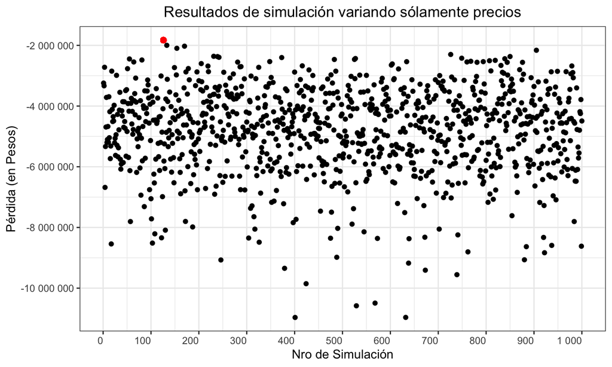

En el punto rojo se marca cuál es el nro de simulación que logró la menor pérdida. Ese punto refiere a la siguiente combinación de precios:

Listado de precios para la menor diferencia

|  | Producto 1 | Producto 2 | Producto 19 | Producto 20 | Diferencia | Flag_Tolerancia |
| --- | --- | --- | --- | --- | --- | --- |
| Simul. 126 | 268 | 403 | 2994 | 2999 | -1827091 | 0 |

## Simulando precios y planes

Ahora vamos a probar simular los precios y a su vez la cantidad de planes, para ver con qué combinación se obtiene la menor pérdida.

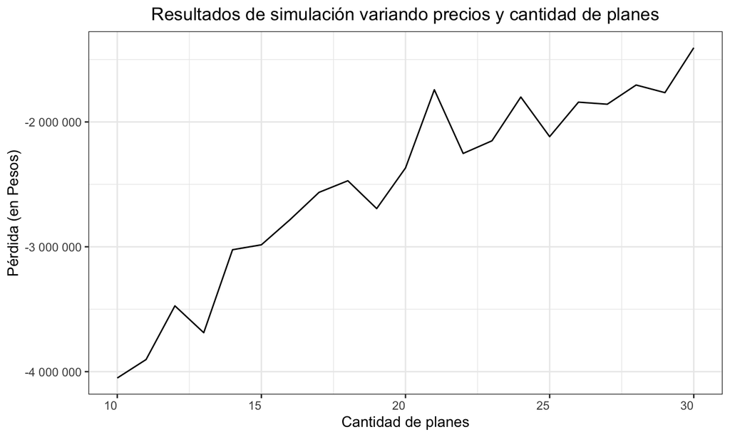

## Simulación con distribuciones Gamma

Ahora probamos aplicar el mismo método de solo uniformes, pero generando los precios con distribuciones gamma y variando el \(\alpha\) y \(\sigma\) de la distribución. Fijamos \(K\) en 20 productos.

Diferencia de precio según Alfa y Sigma

| Alfa | Sigma | Diferencia |
| --- | --- | --- |
| 5.4 | 0.34 | -2667642 |
| 8.0 | 0.61 | -2852771 |
| 10.2 | 0.83 | -3031689 |
| 3.2 | 0.36 | -3054094 |
| 3.6 | 0.25 | -3123105 |

## Conclusiones

Si variamos sólamente precios con uniformes, podemos conseguir a los \(P_{finales}\) posibles y de esos elegir el que menos pérdida genere, auque no estemos 100% seguros de que es la mejor combinación.

Si variamos los precios y a su vez cantidad de planes, se ve una relación de que al aumentar la cantidad de planes, la pérdida disminuye. Esto puede ayudar a la hora de fijar el \(K\)

Comparando contra las distribuciones gamma, no observamos que se logre un mejor resultado. Tal vez si se hicieran más simulaciones o variando \(K\) se pueda lograr un mejor resultado. Tener en cuenta que los valores dados por una gamma no tienen con la forma usual de fijar un precio aunque puede ser un muy buen punto de partida.